# exp2

## ML Lab Experiment No. 02

### Topic: Exploratory Data Analysis (EDA)

### TY IT 24141027

```python
import numpy as np
import pandas as pd
import seaborn as sns
import matplotlib.pyplot as plt

# Display plots inside the notebook
%matplotlib inline

# Set a consistent visual style
sns.set_style("whitegrid")

# Set default figure size
plt.rcParams["figure.figsize"] = (8, 5)

print("Libraries imported successfully.")
```

```
Libraries imported successfully.
```

## Loading Dataset

```python
titanic = pd.read_csv("C:\\Users\\SWARA\\Downloads\\TY\\Sem 5\\ML Lab\\Dataset\\titanic\\train.csv")

print("Titanic dataset loaded successfully.")
```

```
Titanic dataset loaded successfully.
```

## Quick Look Into the Dataset

```python
print("First five rows:")
display(titanic.head())
```

```
First five rows:
```

|  | PassengerId | Survived | Pclass | Name | Sex | Age | SibSp | Parch | Ticket | Fare | Cabin | Embarked |
| --- | --- | --- | --- | --- | --- | --- | --- | --- | --- | --- | --- | --- |
| 0 | 1 | 0 | 3 | Braund, Mr. Owen Harris | male | 22.0 | 1 | 0 | A/5 21171 | 7.2500 | NaN | S |
| 1 | 2 | 1 | 1 | Cumings, Mrs. John Bradley (Florence Briggs Th... | female | 38.0 | 1 | 0 | PC 17599 | 71.2833 | C85 | C |
| 2 | 3 | 1 | 3 | Heikkinen, Miss. Laina | female | 26.0 | 0 | 0 | STON/O2. 3101282 | 7.9250 | NaN | S |
| 3 | 4 | 1 | 1 | Futrelle, Mrs. Jacques Heath (Lily May Peel) | female | 35.0 | 1 | 0 | 113803 | 53.1000 | C123 | S |
| 4 | 5 | 0 | 3 | Allen, Mr. William Henry | male | 35.0 | 0 | 0 | 373450 | 8.0500 | NaN | S |

```python
print("Last five rows:")
display(titanic.tail())
```

```
Last five rows:
```

|  | PassengerId | Survived | Pclass | Name | Sex | Age | SibSp | Parch | Ticket | Fare | Cabin | Embarked |
| --- | --- | --- | --- | --- | --- | --- | --- | --- | --- | --- | --- | --- |
| 886 | 887 | 0 | 2 | Montvila, Rev. Juozas | male | 27.0 | 0 | 0 | 211536 | 13.00 | NaN | S |
| 887 | 888 | 1 | 1 | Graham, Miss. Margaret Edith | female | 19.0 | 0 | 0 | 112053 | 30.00 | B42 | S |
| 888 | 889 | 0 | 3 | Johnston, Miss. Catherine Helen "Carrie" | female | NaN | 1 | 2 | W./C. 6607 | 23.45 | NaN | S |
| 889 | 890 | 1 | 1 | Behr, Mr. Karl Howell | male | 26.0 | 0 | 0 | 111369 | 30.00 | C148 | C |
| 890 | 891 | 0 | 3 | Dooley, Mr. Patrick | male | 32.0 | 0 | 0 | 370376 | 7.75 | NaN | Q |

```python
print("Shape of the dataset:")
print(titanic.shape)
```

```
Shape of the dataset:
(891, 12)
```

```python
print("Column names:")
print(titanic.columns.tolist())
```

```
Column names:
['PassengerId', 'Survived', 'Pclass', 'Name', 'Sex', 'Age', 'SibSp', 'Parch', 'Ticket', 'Fare', 'Cabin', 'Embarked']
```

```python
print("Dataset information:")
titanic.info()
```

```
Dataset information:
<class 'pandas.core.frame.DataFrame'>
RangeIndex: 891 entries, 0 to 890
Data columns (total 12 columns):
 #   Column       Non-Null Count  Dtype
---  ------       --------------  -----
 0   PassengerId  891 non-null    int64
 1   Survived     891 non-null    int64
 2   Pclass       891 non-null    int64
 3   Name         891 non-null    object
 4   Sex          891 non-null    object
 5   Age          714 non-null    float64
 6   SibSp        891 non-null    int64
 7   Parch        891 non-null    int64
 8   Ticket       891 non-null    object
 9   Fare         891 non-null    float64
 10  Cabin        204 non-null    object
 11  Embarked     889 non-null    object
dtypes: float64(2), int64(5), object(5)
memory usage: 83.7+ KB
```

## Basic Information About the Dataset

```python
print("Number of rows:", titanic.shape[0])
print("Number of columns:", titanic.shape[1])

print("\nData types:")
print(titanic.dtypes)
```

```
Number of rows: 891
Number of columns: 12

Data types:
PassengerId      int64
Survived         int64
Pclass           int64
Name            object
Sex             object
Age            float64
SibSp            int64
Parch            int64
Ticket          object
Fare           float64
Cabin           object
Embarked        object
dtype: object
```

```python
print("Number of unique values in each column:")

for column in titanic.columns:
    print(f"{column}: {titanic[column].nunique()}")
```

```
Number of unique values in each column:
PassengerId: 891
Survived: 2
Pclass: 3
Name: 891
Sex: 2
Age: 88
SibSp: 7
Parch: 7
Ticket: 681
Fare: 248
Cabin: 147
Embarked: 3
```

## Statistical Summary

```python
print("Statistical summary of numerical features:")
display(titanic.describe())
```

```
Statistical summary of numerical features:
```

|  | PassengerId | Survived | Pclass | Age | SibSp | Parch | Fare |
| --- | --- | --- | --- | --- | --- | --- | --- |
| count | 891.000000 | 891.000000 | 891.000000 | 714.000000 | 891.000000 | 891.000000 | 891.000000 |
| mean | 446.000000 | 0.383838 | 2.308642 | 29.699118 | 0.523008 | 0.381594 | 32.204208 |
| std | 257.353842 | 0.486592 | 0.836071 | 14.526497 | 1.102743 | 0.806057 | 49.693429 |
| min | 1.000000 | 0.000000 | 1.000000 | 0.420000 | 0.000000 | 0.000000 | 0.000000 |
| 25% | 223.500000 | 0.000000 | 2.000000 | 20.125000 | 0.000000 | 0.000000 | 7.910400 |
| 50% | 446.000000 | 0.000000 | 3.000000 | 28.000000 | 0.000000 | 0.000000 | 14.454200 |
| 75% | 668.500000 | 1.000000 | 3.000000 | 38.000000 | 1.000000 | 0.000000 | 31.000000 |
| max | 891.000000 | 1.000000 | 3.000000 | 80.000000 | 8.000000 | 6.000000 | 512.329200 |

```python
print("Transposed statistical summary:")
display(titanic.describe().transpose())
```

```
Transposed statistical summary:
```

|  | count | mean | std | min | 25% | 50% | 75% | max |
| --- | --- | --- | --- | --- | --- | --- | --- | --- |
| PassengerId | 891.0 | 446.000000 | 257.353842 | 1.00 | 223.5000 | 446.0000 | 668.5 | 891.0000 |
| Survived | 891.0 | 0.383838 | 0.486592 | 0.00 | 0.0000 | 0.0000 | 1.0 | 1.0000 |
| Pclass | 891.0 | 2.308642 | 0.836071 | 1.00 | 2.0000 | 3.0000 | 3.0 | 3.0000 |
| Age | 714.0 | 29.699118 | 14.526497 | 0.42 | 20.1250 | 28.0000 | 38.0 | 80.0000 |
| SibSp | 891.0 | 0.523008 | 1.102743 | 0.00 | 0.0000 | 0.0000 | 1.0 | 8.0000 |
| Parch | 891.0 | 0.381594 | 0.806057 | 0.00 | 0.0000 | 0.0000 | 0.0 | 6.0000 |
| Fare | 891.0 | 32.204208 | 49.693429 | 0.00 | 7.9104 | 14.4542 | 31.0 | 512.3292 |

```python
print("Statistical summary of categorical features:")
display(titanic.describe(include="object"))
```

```
Statistical summary of categorical features:
```

|  | Name | Sex | Ticket | Cabin | Embarked |
| --- | --- | --- | --- | --- | --- |
| count | 891 | 891 | 891 | 204 | 889 |
| unique | 891 | 2 | 681 | 147 | 3 |
| top | Dooley, Mr. Patrick | male | 347082 | G6 | S |
| freq | 1 | 577 | 7 | 4 | 644 |

## Survival Analysis

```python
survival_counts = titanic["Survived"].value_counts()

print("Survival counts:")
print(survival_counts)
```

```
Survival counts:
Survived
0    549
1    342
Name: count, dtype: int64
```

```python
print("Survival counts with labels:")

print("Did not survive:", survival_counts.get(0, 0))
print("Survived:", survival_counts.get(1, 0))
```

```
Survival counts with labels:
Did not survive: 549
Survived: 342
```

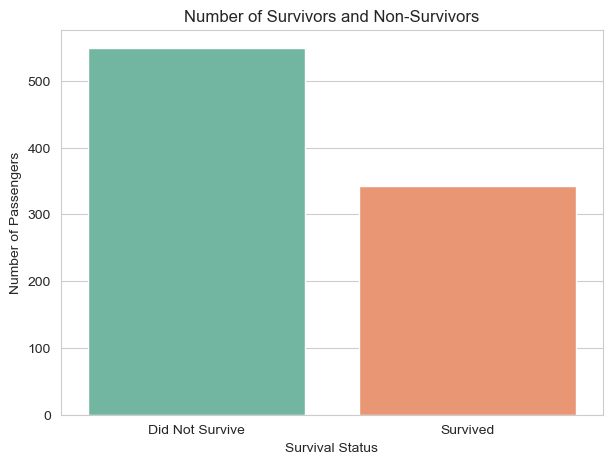

```python
plt.figure(figsize=(7, 5))

sns.countplot(data=titanic, x="Survived", hue="Survived", palette="Set2", legend=False)

plt.title("Number of Survivors and Non-Survivors")
plt.xlabel("Survival Status")
plt.ylabel("Number of Passengers")
plt.xticks([0, 1], ["Did Not Survive", "Survived"])

plt.show()
```

## Analysis of Passenger Class

```python
print("Passenger class counts:")
print(titanic["Pclass"].value_counts().sort_index())
```

```
Passenger class counts:
Pclass
1    216
2    184
3    491
Name: count, dtype: int64
```

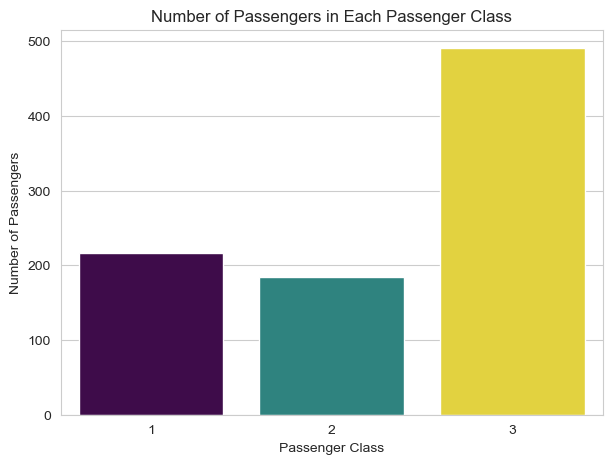

```python
plt.figure(figsize=(7, 5))

sns.countplot(
    data=titanic,
    x="Pclass",
    hue="Pclass",
    palette="viridis",
    legend=False
)

plt.title("Number of Passengers in Each Passenger Class")
plt.xlabel("Passenger Class")
plt.ylabel("Number of Passengers")

plt.show()
```

## Gender Analysis

```python
gender_counts = titanic["Sex"].value_counts()

print("Gender counts:")
print(gender_counts)
```

```
Gender counts:
Sex
male      577
female    314
Name: count, dtype: int64
```

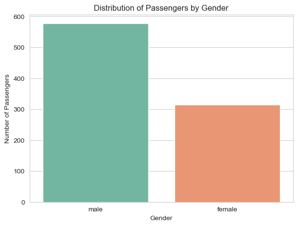

```python
plt.figure(figsize=(7, 5))

sns.countplot(
    data=titanic,
    x="Sex",
    hue="Sex",
    palette="Set2",
    legend=False
)

plt.title("Distribution of Passengers by Gender")
plt.xlabel("Gender")
plt.ylabel("Number of Passengers")

plt.show()
```

## Passengers Younger than 20

```python
less_than_20 = titanic[titanic["Age"] < 20]

print("Passengers younger than 20:")
display(less_than_20.head(10))
```

```
Passengers younger than 20:
```

|  | PassengerId | Survived | Pclass | Name | Sex | Age | SibSp | Parch | Ticket | Fare | Cabin | Embarked |
| --- | --- | --- | --- | --- | --- | --- | --- | --- | --- | --- | --- | --- |
| 7 | 8 | 0 | 3 | Palsson, Master. Gosta Leonard | male | 2.0 | 3 | 1 | 349909 | 21.0750 | NaN | S |
| 9 | 10 | 1 | 2 | Nasser, Mrs. Nicholas (Adele Achem) | female | 14.0 | 1 | 0 | 237736 | 30.0708 | NaN | C |
| 10 | 11 | 1 | 3 | Sandstrom, Miss. Marguerite Rut | female | 4.0 | 1 | 1 | PP 9549 | 16.7000 | G6 | S |
| 14 | 15 | 0 | 3 | Vestrom, Miss. Hulda Amanda Adolfina | female | 14.0 | 0 | 0 | 350406 | 7.8542 | NaN | S |
| 16 | 17 | 0 | 3 | Rice, Master. Eugene | male | 2.0 | 4 | 1 | 382652 | 29.1250 | NaN | Q |
| 22 | 23 | 1 | 3 | McGowan, Miss. Anna "Annie" | female | 15.0 | 0 | 0 | 330923 | 8.0292 | NaN | Q |
| 24 | 25 | 0 | 3 | Palsson, Miss. Torborg Danira | female | 8.0 | 3 | 1 | 349909 | 21.0750 | NaN | S |
| 27 | 28 | 0 | 1 | Fortune, Mr. Charles Alexander | male | 19.0 | 3 | 2 | 19950 | 263.0000 | C23 C25 C27 | S |
| 38 | 39 | 0 | 3 | Vander Planke, Miss. Augusta Maria | female | 18.0 | 2 | 0 | 345764 | 18.0000 | NaN | S |
| 39 | 40 | 1 | 3 | Nicola-Yarred, Miss. Jamila | female | 14.0 | 1 | 0 | 2651 | 11.2417 | NaN | C |

```python
print("Number of passengers younger than 20:")
print(len(less_than_20))
```

```
Number of passengers younger than 20:
164
```

## Embarkation Town Analysis

```python
number_of_towns = titanic["Embarked"].nunique()

print("Number of unique embarkation towns:", number_of_towns)
```

```
Number of unique embarkation towns: 3
```

```python
print("Embarkation town frequencies:")
print(titanic["Embarked"].value_counts())
```

```
Embarkation town frequencies:
Embarked
S    644
C    168
Q     77
Name: count, dtype: int64
```

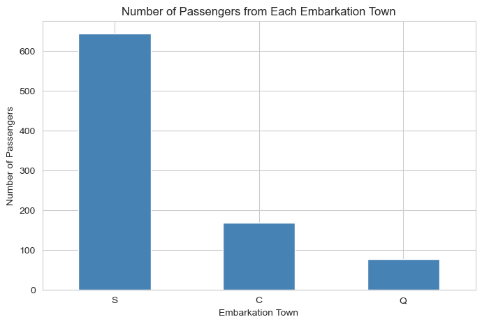

```python
plt.figure(figsize=(8, 5))

titanic["Embarked"].value_counts().plot(
    kind="bar",
    color="steelblue"
)

plt.title("Number of Passengers from Each Embarkation Town")
plt.xlabel("Embarkation Town")
plt.ylabel("Number of Passengers")
plt.xticks(rotation=0)

plt.show()
```

## Missing Data Analysis

```python
missing_values = titanic.isnull().sum()

print("Missing values in each column:")
print(missing_values)
```

```
Missing values in each column:
PassengerId      0
Survived         0
Pclass           0
Name             0
Sex              0
Age            177
SibSp            0
Parch            0
Ticket           0
Fare             0
Cabin          687
Embarked         2
dtype: int64
```

```python
print("Percentage of missing values in each column:")

missing_percentage = (titanic.isnull().sum() / len(titanic)) * 100

display(
    missing_percentage
    .sort_values(ascending=False)
    .to_frame("Missing Percentage")
)
```

```
Percentage of missing values in each column:
```

|  | Missing Percentage |
| --- | --- |
| Cabin | 77.104377 |
| Age | 19.865320 |
| Embarked | 0.224467 |
| PassengerId | 0.000000 |
| Name | 0.000000 |
| Pclass | 0.000000 |
| Survived | 0.000000 |
| Sex | 0.000000 |
| Parch | 0.000000 |
| SibSp | 0.000000 |
| Fare | 0.000000 |
| Ticket | 0.000000 |

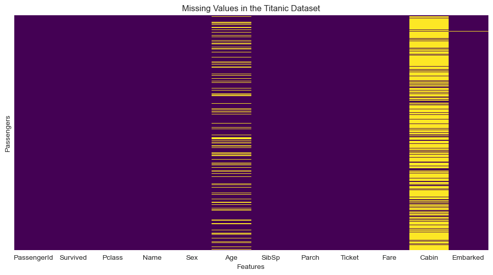

```python
plt.figure(figsize=(12, 6))

sns.heatmap(
    titanic.isnull(),
    yticklabels=False,
    cbar=False,
    cmap="viridis"
)

plt.title("Missing Values in the Titanic Dataset")
plt.xlabel("Features")
plt.ylabel("Passengers")

plt.show()
```

## Survival on the basis of gender

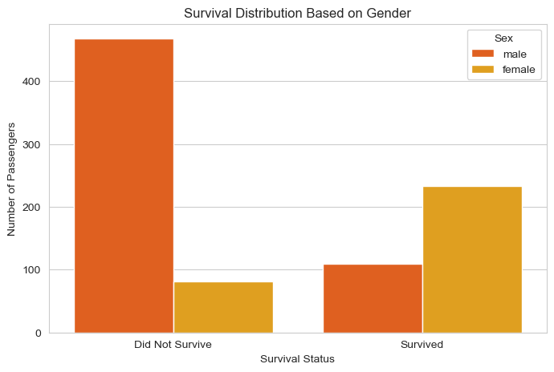

```python
plt.figure(figsize=(8, 5))

sns.countplot(
    data=titanic,
    x="Survived",
    hue="Sex",
    palette="autumn"
)

plt.title("Survival Distribution Based on Gender")
plt.xlabel("Survival Status")
plt.ylabel("Number of Passengers")
plt.xticks([0, 1], ["Did Not Survive", "Survived"])

plt.show()
```

## Survival Based on Passenger Class

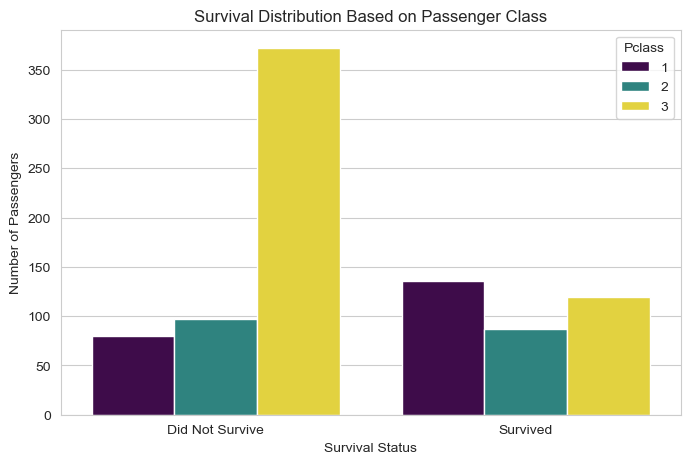

```python
plt.figure(figsize=(8, 5))

sns.countplot(
    data=titanic,
    x="Survived",
    hue="Pclass",
    palette="viridis"
)

plt.title("Survival Distribution Based on Passenger Class")
plt.xlabel("Survival Status")
plt.ylabel("Number of Passengers")
plt.xticks([0, 1], ["Did Not Survive", "Survived"])

plt.show()
```

## Age Distribution

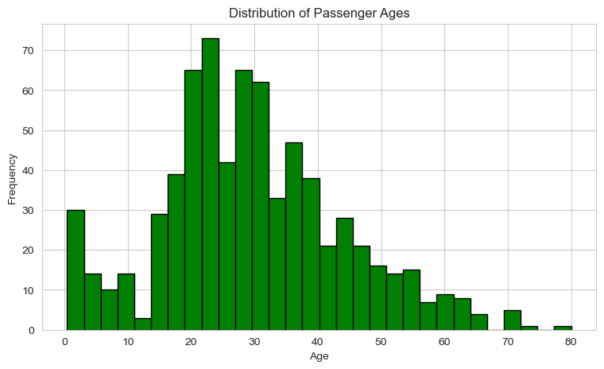

```python
plt.figure(figsize=(9, 5))

titanic["Age"].plot(
    kind="hist",
    bins=30,
    color="green",
    edgecolor="black"
)

plt.title("Distribution of Passenger Ages")
plt.xlabel("Age")
plt.ylabel("Frequency")

plt.show()
```

## Age vs Fare

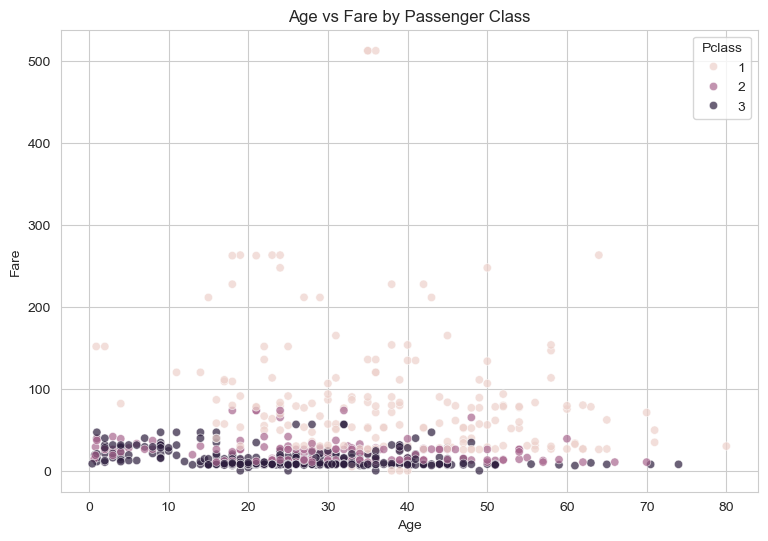

```python
plt.figure(figsize=(9, 6))

sns.scatterplot(
    data=titanic,
    x="Age",
    y="Fare",
    hue="Pclass",
    alpha=0.7
)

plt.title("Age vs Fare by Passenger Class")
plt.xlabel("Age")
plt.ylabel("Fare")

plt.show()
```

## Age vs Fare (Gender-Based)

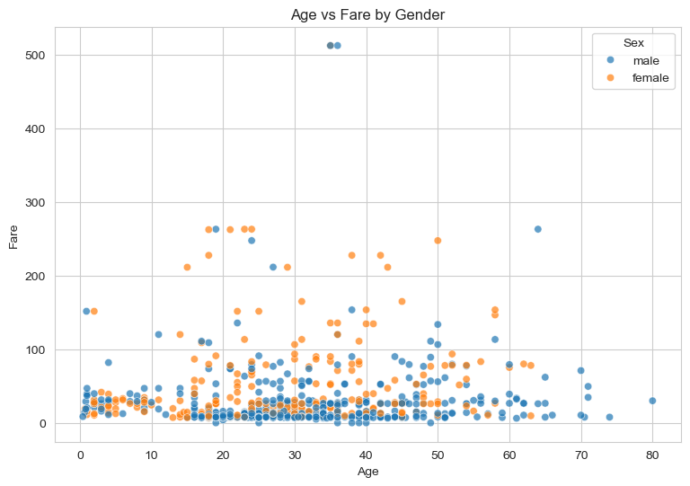

```python
plt.figure(figsize=(9, 6))

sns.scatterplot(
    data=titanic,
    x="Age",
    y="Fare",
    hue="Sex",
    alpha=0.7
)

plt.title("Age vs Fare by Gender")
plt.xlabel("Age")
plt.ylabel("Fare")

plt.show()
```

## Box plot for age and outlier detection

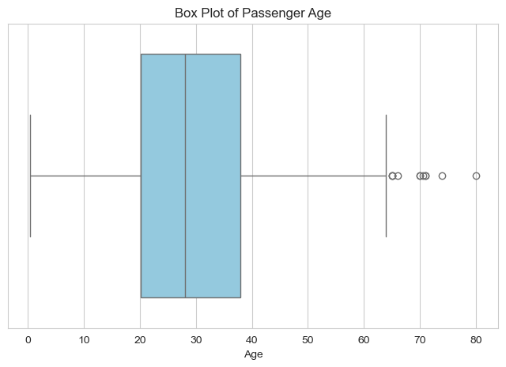

```python
plt.figure(figsize=(8, 5))

sns.boxplot(
    data=titanic,
    x="Age",
    color="skyblue"
)

plt.title("Box Plot of Passenger Age")
plt.xlabel("Age")

plt.show()
```

## Box plot for fare distribution and outlier detection

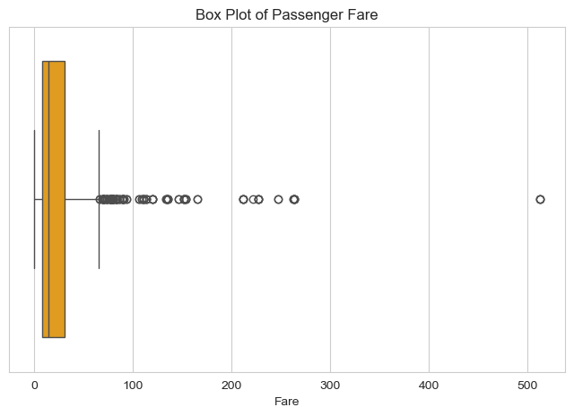

```python
plt.figure(figsize=(8, 5))

sns.boxplot(
    data=titanic,
    x="Fare",
    color="orange"
)

plt.title("Box Plot of Passenger Fare")
plt.xlabel("Fare")

plt.show()
```

## Correlation Analysis

```python
# Select only numerical columns
numerical_data = titanic.select_dtypes(include=np.number)

print("Numerical columns used for correlation analysis:")
print(numerical_data.columns.tolist())
```

```
Numerical columns used for correlation analysis:
['PassengerId', 'Survived', 'Pclass', 'Age', 'SibSp', 'Parch', 'Fare']
```

```python
correlation = numerical_data.corr()

print("Correlation matrix:")
display(correlation)
```

```
Correlation matrix:
```

|  | PassengerId | Survived | Pclass | Age | SibSp | Parch | Fare |
| --- | --- | --- | --- | --- | --- | --- | --- |
| PassengerId | 1.000000 | -0.005007 | -0.035144 | 0.036847 | -0.057527 | -0.001652 | 0.012658 |
| Survived | -0.005007 | 1.000000 | -0.338481 | -0.077221 | -0.035322 | 0.081629 | 0.257307 |
| Pclass | -0.035144 | -0.338481 | 1.000000 | -0.369226 | 0.083081 | 0.018443 | -0.549500 |
| Age | 0.036847 | -0.077221 | -0.369226 | 1.000000 | -0.308247 | -0.189119 | 0.096067 |
| SibSp | -0.057527 | -0.035322 | 0.083081 | -0.308247 | 1.000000 | 0.414838 | 0.159651 |
| Parch | -0.001652 | 0.081629 | 0.018443 | -0.189119 | 0.414838 | 1.000000 | 0.216225 |
| Fare | 0.012658 | 0.257307 | -0.549500 | 0.096067 | 0.159651 | 0.216225 | 1.000000 |

```python
print("Correlation of numerical features with survival:")
display(correlation["Survived"].sort_values(ascending=False))
```

```
Correlation of numerical features with survival:
```

```
Survived       1.000000
Fare           0.257307
Parch          0.081629
PassengerId   -0.005007
SibSp         -0.035322
Age           -0.077221
Pclass        -0.338481
Name: Survived, dtype: float64
```

## Heatmap

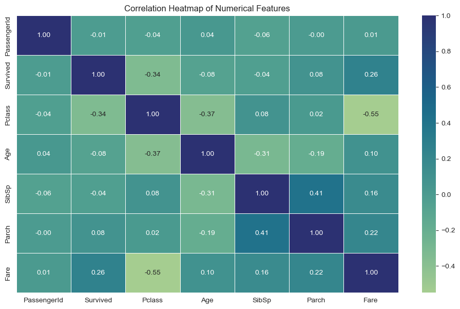

```python
plt.figure(figsize=(12, 7))

sns.heatmap(
    correlation,
    annot=True,
    cmap="crest",
    fmt=".2f",
    linewidths=0.5
)

plt.title("Correlation Heatmap of Numerical Features")

plt.show()
```

## Numerical Data Distribution Analysis

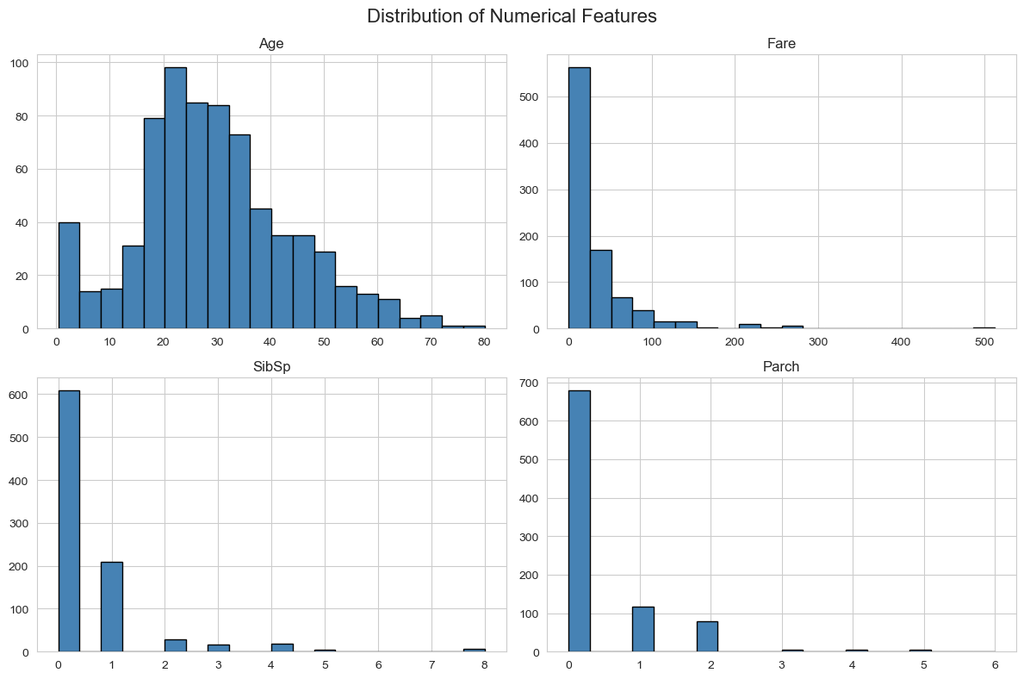

```python
numerical_columns = ["Age", "Fare", "SibSp", "Parch"]

titanic[numerical_columns].hist(
    figsize=(12, 8),
    bins=20,
    color="steelblue",
    edgecolor="black"
)

plt.suptitle("Distribution of Numerical Features", fontsize=16)

plt.tight_layout()

plt.show()
```

## Gender-wise Survival Rate

```python
survival_by_gender = titanic.groupby("Sex", observed=True)["Survived"].mean()

print("Survival rate by gender:")
display(survival_by_gender)
```

```
Survival rate by gender:
```

```
Sex
female    0.742038
male      0.188908
Name: Survived, dtype: float64
```

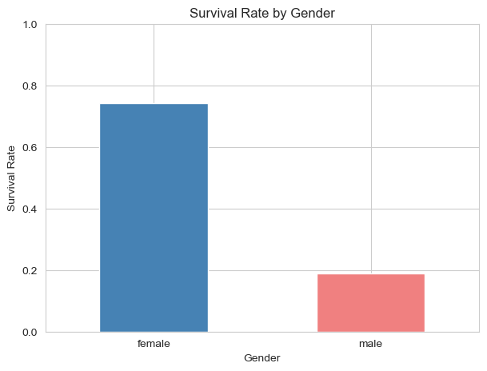

```python
plt.figure(figsize=(7, 5))

survival_by_gender.plot(
    kind="bar",
    color=["steelblue", "lightcoral"]
)

plt.title("Survival Rate by Gender")
plt.xlabel("Gender")
plt.ylabel("Survival Rate")
plt.xticks(rotation=0)

plt.ylim(0, 1)

plt.show()
```

## Conclusion

In this practical, Exploratory Data Analysis (EDA) was performed on the Titanic dataset using Python libraries such as NumPy, Pandas, Matplotlib and Seaborn.

The dataset was first examined using basic information, shape, data types, head and tail operations. Statistical summaries were then generated to understand the central tendency and distribution of numerical features.

Missing values were identified and potential outliers were examined using box plots. Relationships between variables such as age, fare, gender, passenger class and survival were also investigated.

The analysis showed important patterns, particularly the relationship of survival with gender and passenger class. These observations can be useful during feature selection, data preprocessing and development of machine learning models.

Thus, EDA provided a comprehensive understanding of the Titanic dataset and established a foundation for further machine learning analysis.